# AVR

# Introduction

Data was gathered using questionnaires and mark reports. Mark reports were provided by schools and consist of grades and absences. Grades are evaluated in three periods and marked in a 20-point grading scale where 0 is the lowest possible mark and 20 the highest. The former was used to gather the data for the several demographic, social/emotional and school related variables. The final questionnaire containing 37 questions in a single A4 sheet was answered in class by 788 students. Later 111 answers were discarded due to lack of identification details. At the end the data was merged into two samples that related to Mathematics (395) and Portuguese (649) classes.

The merged dataset consist of 13 variables that uniquely identifies each row and 20 that describe their performance at one of the subjects. All the features can be split into categorical and numerical ones, but we are rather interested in analyzing the variables rather than the right survey distribution.

```r
index <- c("school","sex","age","address","famsize","Pstatus","Medu","Fedu","Mjob","Fjob","reason","nursery","internet")
index
```

```
##  [1] "school"   "sex"      "age"      "address"  "famsize"  "Pstatus"
##  [7] "Medu"     "Fedu"     "Mjob"     "Fjob"     "reason"   "nursery"
## [13] "internet"
```

```r
source("read_data.R")
source("plot_functions.R")
master_data <- read_data()
dictionary <- read_excel("dictionary.xlsx")
```

Let’s plot the dependency between grades in Math and Portugese subjects.

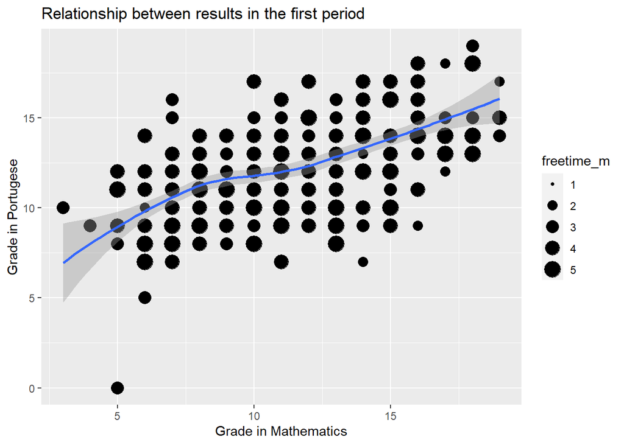

```r
ggplot(master_data, aes(G1_m, G1_p)) +
  geom_point(aes(size = freetime_m)) +
  geom_smooth() +
  labs(x = "Grade in Mathematics",
       y = "Grade in Portugese",
       title = "Relationship between results in the first period")
```

When analyzing the dataset it confused us that there are two separate columns for health. We were convinced that this should be gathered only once during the research. The decision was made to check how attending the particular subject influences the responses.

```r
health_eq_acc_points <- master_data %>%
        mutate(health_eq = if_else(health_m == health_p, 1, 0)) %>%
        group_by(health_m, health_p) %>%
        summarise(cnt = n())
```

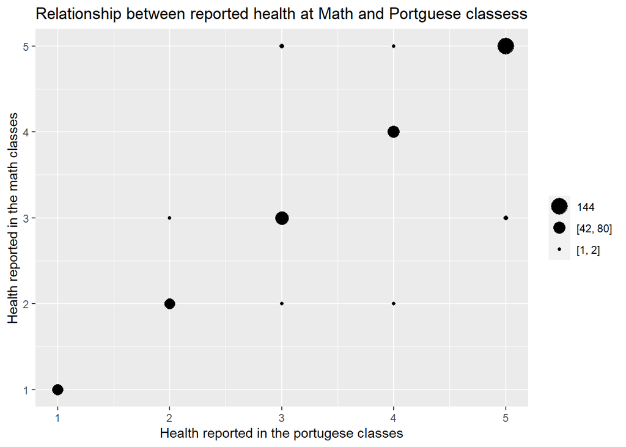

```r
ggplot(master_data %>%
               inner_join(health_eq_acc_points),
       aes(x = health_m, y = health_p, size = cnt)) +
        scale_size(name   = "",
                   breaks = c(144, 61, 1),
                   labels = c('144', '[42, 80]', '[1, 2]')) +
        geom_point() +
        labs(y = 'Health reported in the math classes',
             x = 'Health reported in the portugese classes',
             title = 'Relationship between reported health at Math and Portguese classess')
```

Most students reported the same health condition in Math and Portuguese classes.

# Question 2

What kind of support students with each subject?

```r
sum(master_data$paid_m != master_data$paid_p)
```

```
## [1] 171
```

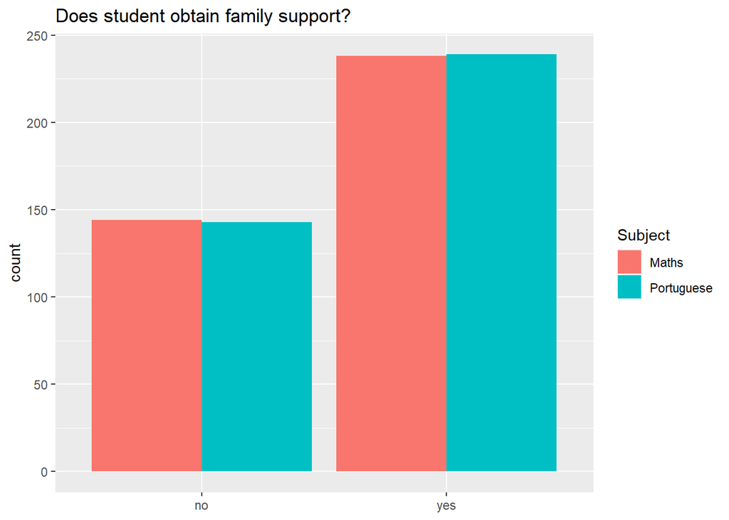

```r
# subject support from family

master_data %>% select(famsup_m,famsup_p) %>% mutate(n=1) %>% pivot_longer(!n) %>%
  ggplot(aes(x = value, fill = name)) +
  geom_bar(stat = "count", position = "dodge") +
  scale_fill_discrete(name = "Subject", labels = c("Maths", "Portuguese"))+
  ggtitle("Does student obtain family support?")+
  xlab(NULL)
```

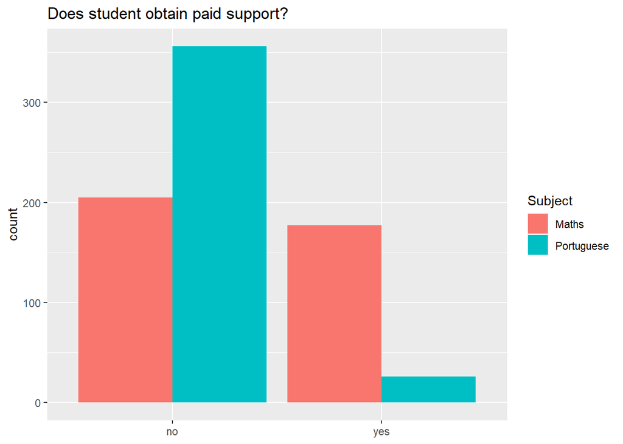

```r
# paid support
master_data %>% select(paid_m,paid_p) %>% mutate(n=1) %>% pivot_longer(!n) %>%
  ggplot(aes(x = value, fill = name)) +
  geom_bar(stat = "count", position = "dodge")+
  scale_fill_discrete(name = "Subject", labels = c("Maths", "Portuguese"))+
  ggtitle("Does student obtain paid support?")+
  xlab(NULL)
```

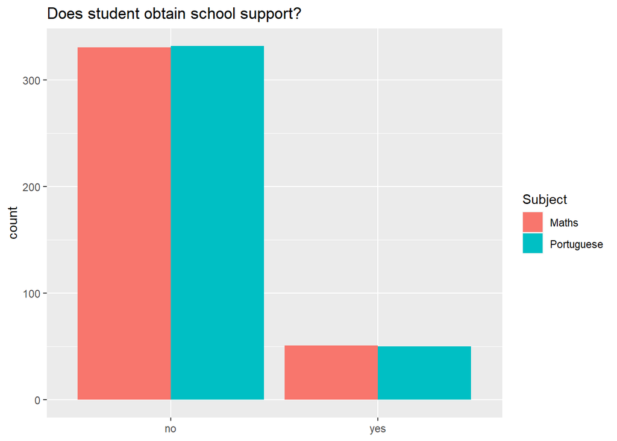

```r
# school support
master_data %>% select(schoolsup_m,schoolsup_p) %>% mutate(n=1) %>% pivot_longer(!n) %>%
  ggplot(aes(x = value, fill = name)) +
  geom_bar(stat = "count", position = "dodge")+
  scale_fill_discrete(name = "Subject", labels = c("Maths", "Portuguese"))+
  ggtitle("Does student obtain school support?")+
  xlab(NULL)
```

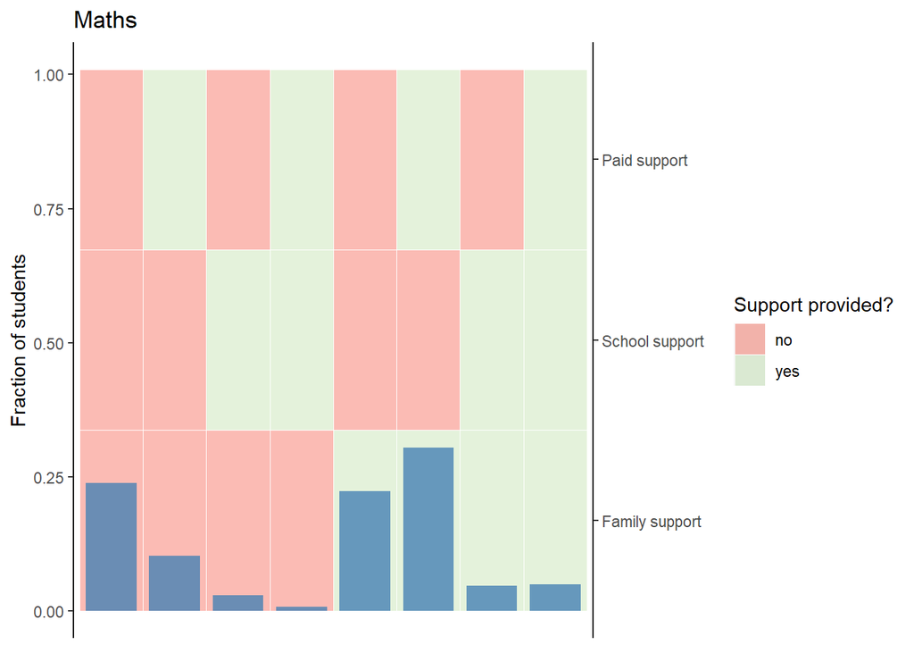

```r
# better varsion of barplot to answer the quesition MATHS

# create additional variables

master_data %>% group_by(famsup_m,schoolsup_m,paid_m) %>%
  summarise(n = n(), grade = mean(G3_m)) %>%
  arrange(-grade) %>% pivot_longer(c(famsup_m,schoolsup_m,paid_m)) %>%
  mutate(bg_color = ifelse(value == "yes", "green","red")) ->tmp_1
supp_m <- master_data %>% group_by(famsup_m,schoolsup_m,paid_m) %>%
  summarise(n = n(), grade = mean(G3_m), .groups = "rowwise") %>%
  mutate(cat_name = paste("f",famsup_m,"s",schoolsup_m,"p",paid_m,sep = '_')) %>%
  mutate(id = cur_group_id())

tmp_1 <- supp_m  %>% pivot_longer(c(famsup_m,schoolsup_m,paid_m))
## tiles
# calculate positions of tiles
max_n <- 1#max(supp_m$n)
tile_half_height <- (max_n*1.01)/6
tile_y_middles <- c(tile_half_height,3*tile_half_height,5*tile_half_height)

tiles_df <- data.frame(
  x = rep(seq(1,8,1), 3),
  y = rep(tile_y_middles, each = 8)
)%>% arrange(x) %>% mutate(z = tmp_1$value)

#maths
supp_plot_m <- ggplot() +
  geom_tile(data = tiles_df, aes(x, y,fill = z), colour = "white", alpha = 0.3)+
  scale_fill_manual(breaks=c("no","yes"),values=c("#f21a02","#a3d487"), name = "Support provided?")+
  scale_x_discrete()+
  geom_col(data = supp_m, aes(x=cat_name,y=n/sum(n)), alpha = 0.8, width = 0.8, fill = "steelblue")+
  scale_y_continuous(breaks = seq(0,1, length.out = 5)
                    ,sec.axis = sec_axis( ~.,
                                          breaks =c(tile_half_height,3*tile_half_height,5*tile_half_height),
                                          labels = c("Family support","School support", "Paid support")))+
  theme(axis.title.x=element_blank(),
        axis.text.x=element_blank(),
        axis.ticks.x=element_blank(),
        panel.background = element_blank(),
        axis.line.y = element_line())+
  ylab("Fraction of students")+
  ggtitle("Maths")

supp_plot_m
```

```r
# better varsion of barplot to answer the quesition PORT

# create additional variables

master_data %>% group_by(famsup_p,schoolsup_p,paid_p) %>%
  summarise(n = n(), grade = mean(G3_p)) %>%
  arrange(-grade) %>% pivot_longer(c(famsup_p,schoolsup_p,paid_p)) %>%
  mutate(bg_color = ifelse(value == "yes", "green","red")) ->tmp_1
supp_p <- master_data %>% group_by(famsup_p,schoolsup_p,paid_p) %>%
  summarise(n = n(), grade = mean(G3_p), .groups = "rowwise") %>%
  mutate(cat_name = paste("f",famsup_p,"s",schoolsup_p,"p",paid_p,sep = '_')) %>%
  mutate(id = cur_group_id())

tmp_1 <- supp_p  %>% pivot_longer(c(famsup_p,schoolsup_p,paid_p))
## tiles
# calculate positions of tiles
max_n <- max(supp_p$n)
tile_half_height <- (max_n+2)/6
tile_y_middles <- c(tile_half_height,3*tile_half_height,5*tile_half_height)

tiles_df <- data.frame(
  x = rep(seq(1,8,1), 3),
  y = rep(tile_y_middles, each = 8)
)%>% arrange(x) %>% mutate(z = tmp_1$value)


supp_plot_p <- ggplot() +
  geom_tile(data = tiles_df, aes(x, y,fill = z), colour = "white", alpha = 0.3)+
  scale_fill_manual(breaks=c("no","yes"),values=c("#f21a02","#a3d487"), name = "Support provided?")+
  scale_x_discrete()+
  geom_col(data = supp_p, aes(x=cat_name,y=n), alpha = 0.8, width = 0.8, fill = "steelblue")+
  scale_y_continuous(breaks = seq(10,max(supp_p$n), length.out = 5) %>% round()
                    ,sec.axis = sec_axis( ~.,
                                          breaks =c(tile_half_height,3*tile_half_height,5*tile_half_height),
                                          labels = c("Family support","School support", "Paid support")))+
  theme(axis.title.x=element_blank(),
        axis.text.x=element_blank(),
        axis.ticks.x=element_blank(),
        panel.background = element_blank(),
        axis.line.y = element_line())+
  ylab("Number of students")+
  ggtitle("Portuguese")
```

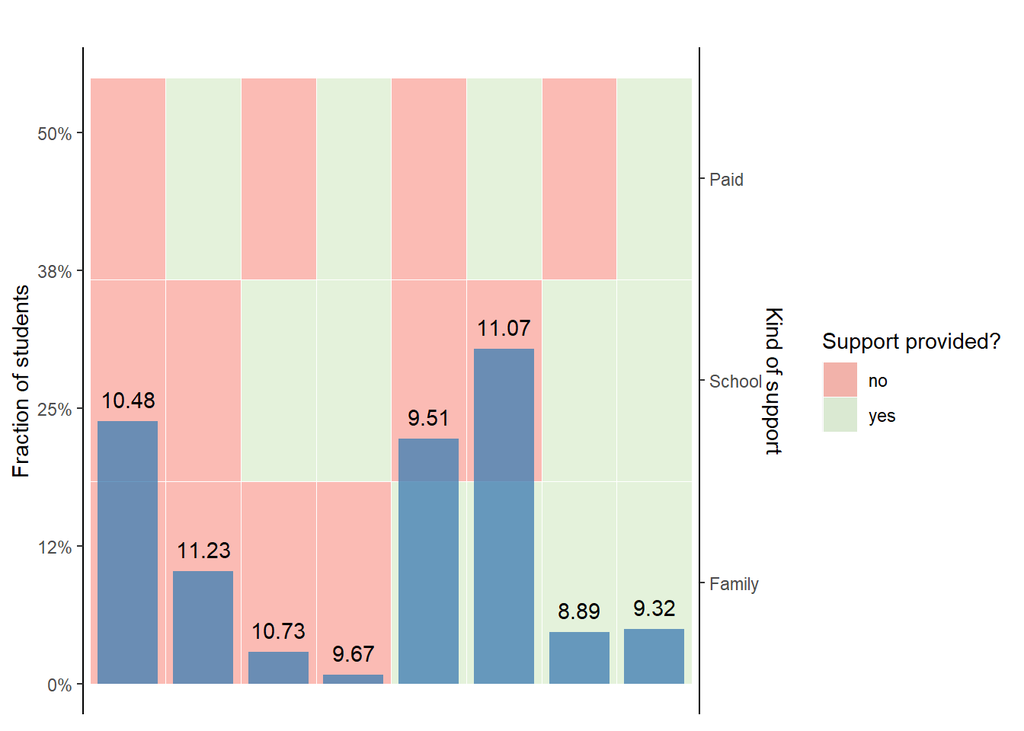

```r
supp_plot_m <- make_barplot_with_bg_tiles(master_data,famsup_m,schoolsup_m,paid_m,G3_m,
                                          title = '')
supp_plot_p <- make_barplot_with_bg_tiles(master_data,famsup_p,schoolsup_p,paid_p,G3_p)
supp_plot_m
```

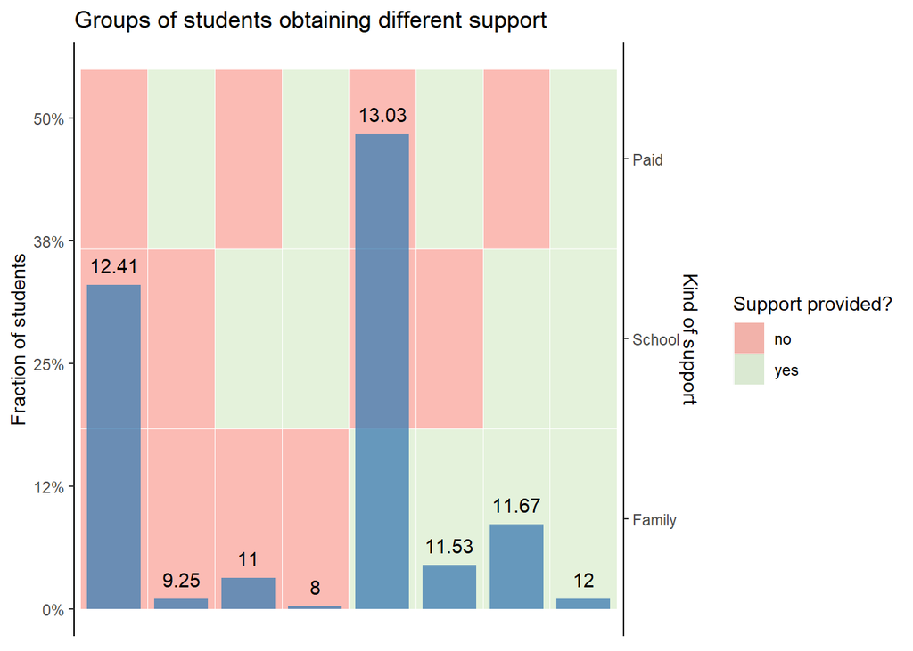

```r
supp_plot_p
```

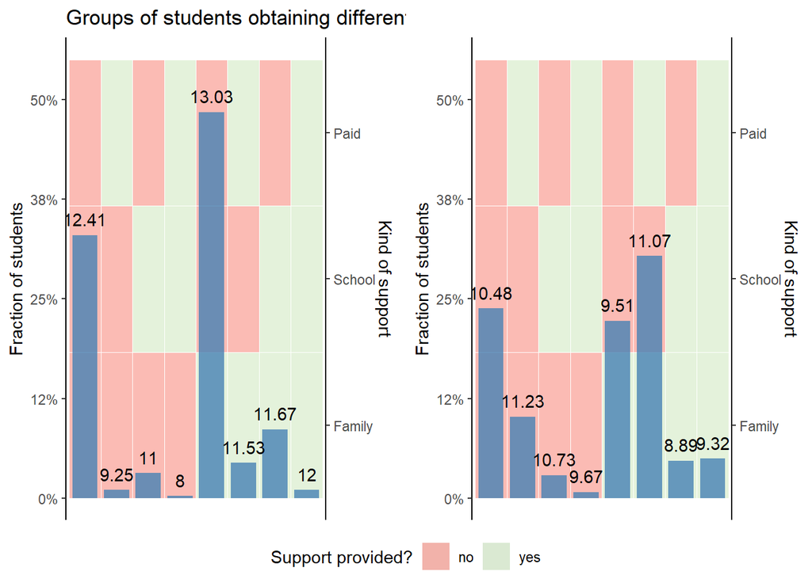

```r
ggarrange(supp_plot_p,supp_plot_m,common.legend = T , legend = "bottom")
```

# Question 3

Do students improve their grades during the year?

```r
# attempt 1
# data
tmp1 <- master_data %>%
  select(matches("G._m")) %>%
  drop_na()%>%
  mutate(across(everything(),
                ~cut(.x,breaks = c(-1,7,15,21),
                    labels = c("low","medium","high")))) %>%
  group_by(G1_m,G2_m) %>%
  summarise(n = n()) %>%
  mutate(G1_m = paste0("First ",G1_m),
         G2_m = paste0("Second ",G2_m)) %>%
  arrange(-n)
```

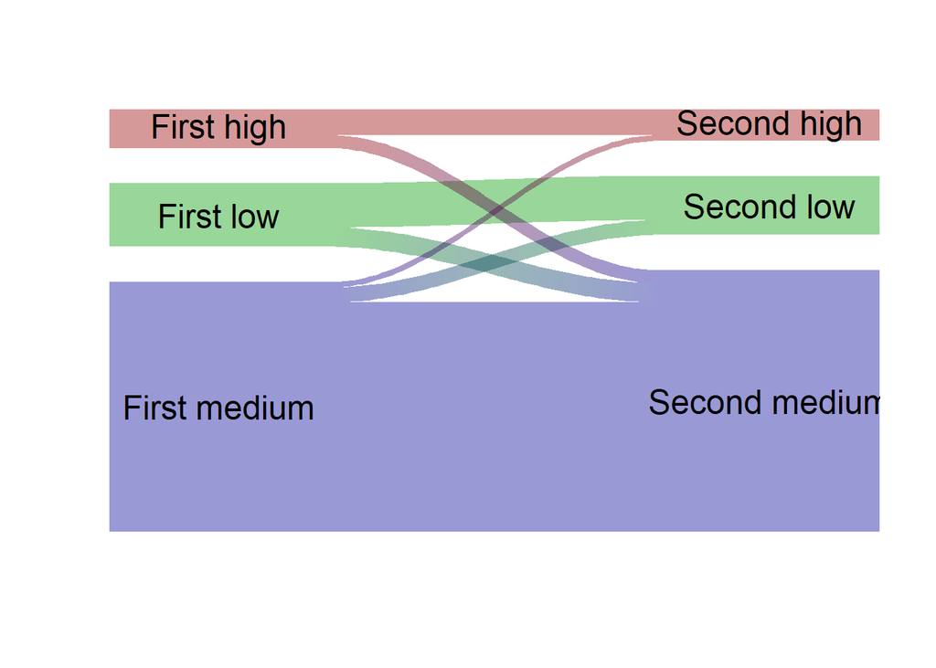

```r
# final plot
nodes <- data.frame(ID = unique(c(tmp1$G1_m,tmp1$G2_m)),
                    x = c(rep(1,3),rep(2,3)))
edges <- data.frame(ID = 1:nrow(tmp1),
                    N1 = tmp1$G1_m,
                    N2 = tmp1$G2_m,
                    Value = tmp1$n)
cols <- c(low="#00990066",
medium="#00009966",
high ="#99000066")
style <- sapply(nodes$ID, function(id)
list(col=cols[ gsub("(First|Second) ", "", id) ]), simplify=FALSE)


r <- makeRiver(nodes,edges,styles =style)
d <- list(srt=0, textcex=1.5) # default style
plot(r, plot_area=1, nodewidth=10, default_style=d)
```

```r
grade_per_subject_long <-
  master_data %>%
  mutate(row_num = row_number()) %>%
  select(row_num, starts_with("G", ignore.case = FALSE)) %>%
  pivot_longer(-row_num) %>%
  separate(name, c("grade", "subject"))
```

```r
subject_pretty_names <- tibble(short_name = c('m', 'p'),
                               pretty_name = c('Mathematics','Portugese'))
```

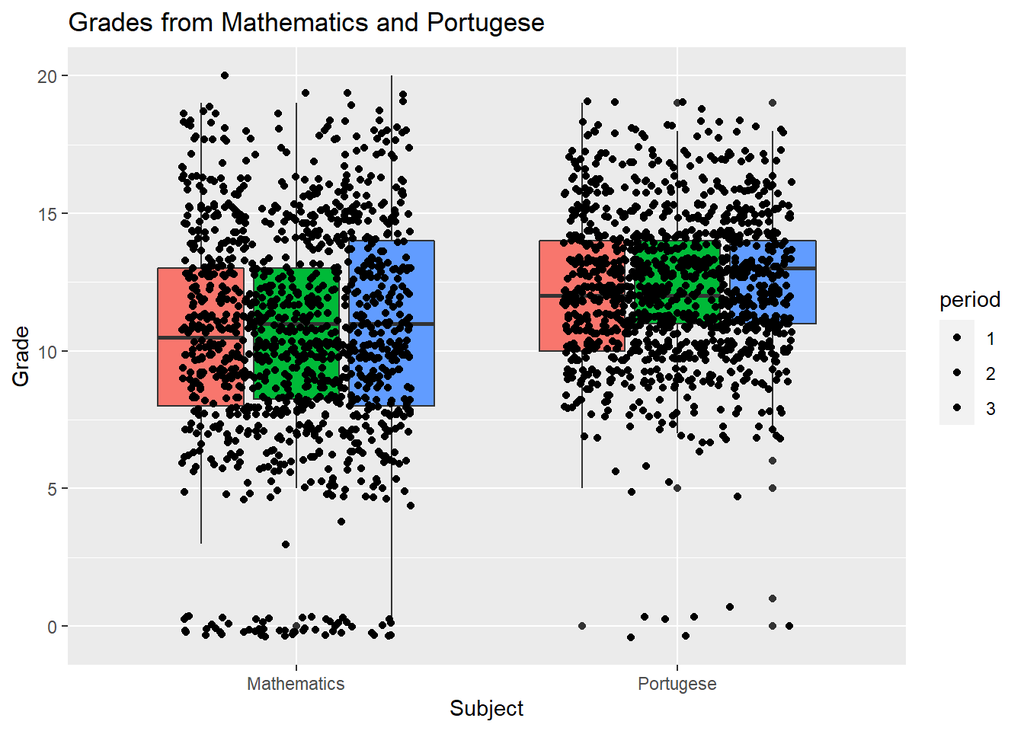

```r
ggplot(data = grade_per_subject_long %>%
  inner_join(subject_pretty_names,
             by = c("subject" = "short_name")) %>% separate(grade, 1, into = c("to_remove", "period")),
       aes(y = value, x = pretty_name, fill = period)) +
  geom_boxplot(show.legend = F) +
  geom_jitter(width = .3) +
  ggtitle("Grades from Mathematics and Portugese") +
  labs(x = "Subject", y = "Grade")
```

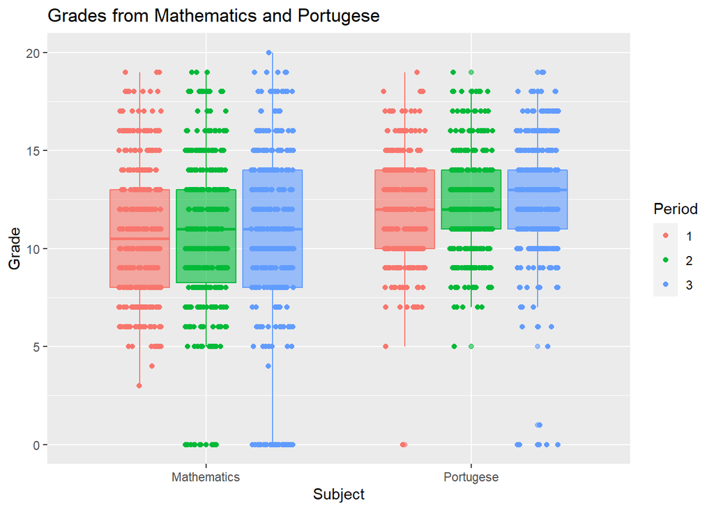

```r
ggplot(data = grade_per_subject_long %>%
  inner_join(subject_pretty_names,
             by = c("subject" = "short_name")) %>% separate(grade, 1, into = c("to_remove", "period")),
       aes(y = value, x = factor(pretty_name), fill = factor(period), colour=factor(period))) +
  geom_boxplot(alpha = 0.6, show.legend = F) +
  geom_point(position = position_jitterdodge()) +
  ggtitle("Grades from Mathematics and Portugese") +
  labs(x = "Subject", y = "Grade", colour = "Period") + guides(fill=FALSE)
```

```r
grade_per_subject_long <-
  master_data %>%
  mutate(row_num = row_number()) %>%
  select(row_num, starts_with("G", ignore.case = FALSE)) %>%
  pivot_longer(-row_num) %>%
  separate(name, c("grade", "subject"))
```

```r
subject_pretty_names <- tibble(short_name = c('m', 'p'),
                               pretty_name = c('Mathematics','Portugese'))
```

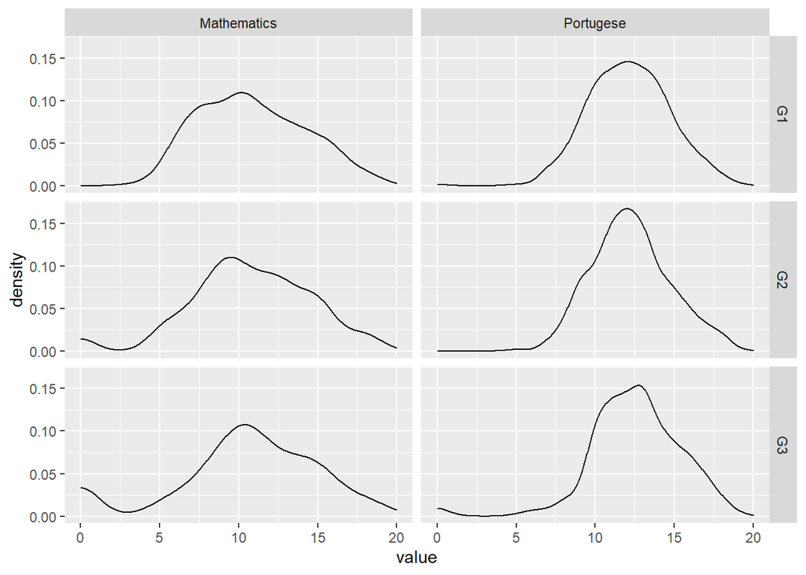

```r
grade_per_subject_long %>%
  inner_join(subject_pretty_names, by = c("subject" = 'short_name')) %>%
  ggplot(aes(x = value)) +
  geom_density() +
  facet_grid(grade~pretty_name)
```

Grades for Portugese were consistently higher than in Mathematics. We do not observe neither a positive nor negative trend relating to the subsequent periods results’.

```r
grade_per_subject_long <-
  master_data %>%
  mutate(row_num = row_number()) %>%
  select(row_num, starts_with("G", ignore.case = FALSE)) %>%
  pivot_longer(-row_num) %>%
  separate(name, c("grade", "subject"))

absences.agg <- master_data %>%
  group_by(freetime_m, goout_m) %>%
  summarise(across(absences_m, ~n()))
```

```r
low.high.map <- tibble(ugly_level = c(1, 2, 3, 4, 5),
                         pretty_level = c('very low',
                                               'low',
                                               'medium',
                                               'high',
                                               'very high'))

absences.agg.to.plot.m <- absences.agg %>%
  ungroup() %>%
  inner_join(low.high.map,
             by = c("freetime_m" = "ugly_level")) %>%
  rename( freetime_pretty = pretty_level) %>%
  inner_join(low.high.map,
             by = c("goout_m" = "ugly_level")) %>%
  rename( goout_pretty = pretty_level) %>% select(freetime_pretty, goout_pretty, absences_m)

absences.m.plot <-
  ggplot(absences.agg.to.plot.m, aes(x = freetime_pretty, y = goout_pretty)) + # nowa baza danych
  geom_tile(aes(fill = absences_m), color = 'white', show.legend = F) +
  theme_minimal() +
  geom_text(aes(label = absences_m), size = 5, fontface = 'bold', color = 'white') +
    theme(panel.grid = element_blank(),
          axis.title.x = element_blank(),
          axis.title.y = element_blank()) + ggtitle('Mathematics')
```

```r
absences.agg <- master_data %>%
  group_by(freetime_p, goout_p) %>%
  summarise(across(absences_p, ~n()))
```

```r
low.high.map <- tibble(ugly_level = c(1, 2, 3, 4, 5),
                       pretty_level = c('very low',
                                        'low',
                                        'medium',
                                        'high',
                                        'very high'))
```

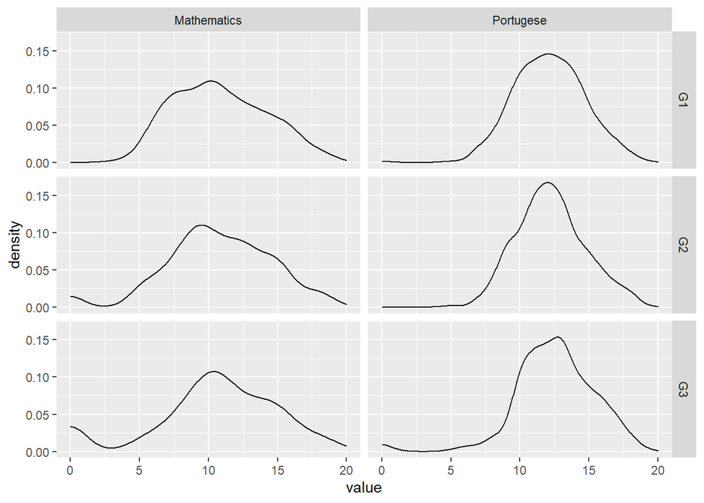

```r
grade_per_subject_long %>%
  inner_join(subject_pretty_names, by = c("subject" = 'short_name')) %>%
  ggplot(aes(x = value)) +
  geom_density() +
  facet_grid(grade~pretty_name)
```

```r
absences.agg.to.plot.p <- absences.agg %>%
  ungroup() %>%
  inner_join(low.high.map,
             by = c("freetime_p" = "ugly_level")) %>%
  rename( freetime_pretty = pretty_level) %>%
  inner_join(low.high.map,
             by = c("goout_p" = "ugly_level")) %>%
  rename( goout_pretty = pretty_level) %>% select(freetime_pretty, goout_pretty, absences_p)
```

```r
absences.p.plot <-
ggplot(absences.agg.to.plot.p, aes(x = freetime_pretty, y = goout_pretty)) + # nowa baza danych
  geom_tile(aes(fill = absences_p), color = 'white', show.legend = F) +
  theme_minimal() +
  geom_text(aes(label = absences_p), size = 5, fontface = 'bold', color = 'white') +
  theme(panel.grid = element_blank(),
axis.title.x = element_blank(),
        axis.title.y = element_blank()) + ggtitle('Portugese')
```

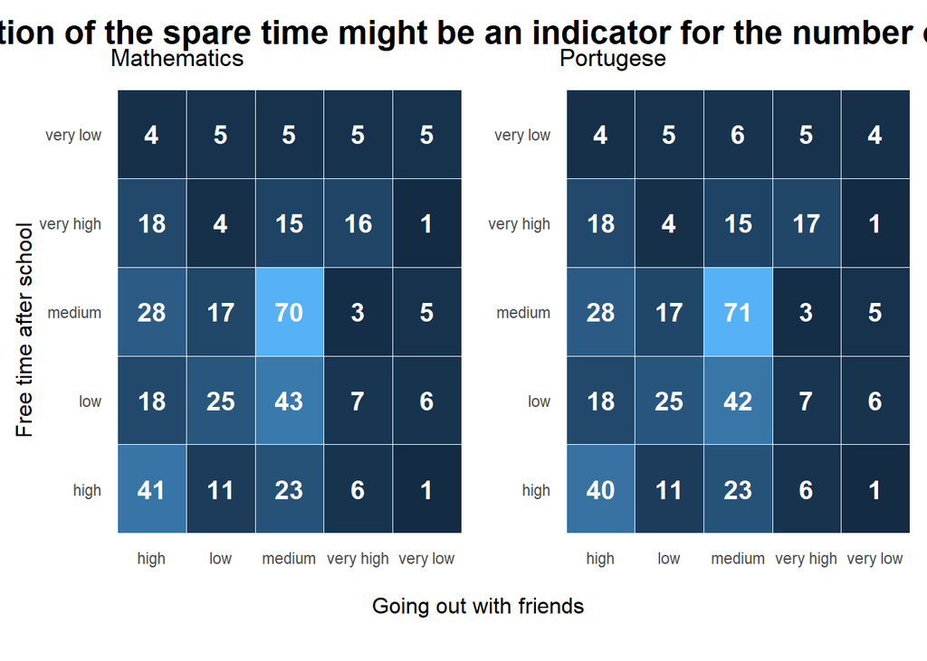

```r
grid.arrange(arrangeGrob(absences.m.plot + theme(legend.position = "none"),
                         absences.p.plot + theme(legend.position = "none"),
                         ncol = 2),
             nrow = 2,
             heights = c(10, 1), # relative height of two rows
             top = textGrob("Consideration of the spare time might be an indicator for the number of absences.", vjust = 1, gp = gpar(fontface = "bold", cex = 1.5)),
             left = textGrob("Free time after school", rot = 90, vjust = 1),
             bottom = textGrob("Going out with friends", rot = 0, vjust = -2)
)
```

# References

Cortez, Paulo, and Alice Silva. 2008. “Using data mining to predict secondary school student performance.” *15th European Concurrent Engineering Conference 2008, ECEC 2008 - 5th Future Business Technology Conference, FUBUTEC 2008*, no. January 2008: 5–12.